# Causal Inference of Labor Market Inequality Using PGM: A multidimensional analysis of unemployment rate

### 4.2 Race model - Define the prior means for overall population

```python
### population unemployment mean probability from the fitted Weibull distribution
weibull_fitted_mean_prob = 0.0435
# Convert the fitted mean probability to its log-odds equivalent in order to model binary outcome with logistic regression
population_mean_log_odds = np.log(weibull_fitted_mean_prob / (1 - weibull_fitted_mean_prob))
print(f"population mean log-odds: {population_mean_log_odds:.4f}")
```

```
population mean log-odds: -3.0905
```

### 4.3 Race model - Define the prior means by races

```python
# Function to find the means of different demographics
def mean_prob_demographic(df_name, demographic_type, demographic_description):
    demographic_mean_prob = df_dic[df_name].loc[df_dic[df_name][demographic_type]==demographic_description]['Unemployment_rate'].mean()/100
    demographic_mean_log_odds = np.log(demographic_mean_prob / (1 - demographic_mean_prob))
    # beta_effect is the difference between the demographic group mean log-odds and the population mean log-odds
    beta_effect = demographic_mean_log_odds - population_mean_log_odds
    return beta_effect

# Create a grid of demographic information to return the means
demographic_grid = pd.DataFrame({
    "df_name":[
        'Race',
        'Race',
        'Race'
    ],
    "demographic_type":[
        "Race",
        "Race",
        "Race"
    ],
    "demographic_description":[
        'black_and_african',
        'white',
        'asian'
    ]
})
# Return the beta_effect of different demographics
demographic_grid['beta_effect']= np.float64(0)
for row in range(0,len(demographic_grid)):
    # Mean of demographic groups
    beta_effect = mean_prob_demographic(demographic_grid['df_name'][row], demographic_grid['demographic_type'][row], demographic_grid['demographic_description'][row])
    demographic_grid['beta_effect'][row] = beta_effect

display(demographic_grid)
```

|  | df_name | demographic_type | demographic_description | beta_effect |
| --- | --- | --- | --- | --- |
| 0 | Race | Race | black_and_african | 0.579129 |
| 1 | Race | Race | white | -0.051353 |
| 2 | Race | Race | asian | -0.105245 |

The corresponding beta_effect for each of three races are shown in table above. These beta parameters are additive race effect parameter on population mean.

### 4.4 Race model - Train-test split

Before PyMC - Split survey data to train and test datasets in order to test the performance of the models

```python
from sklearn.model_selection import train_test_split
train_df_survey, test_df_survey = train_test_split(df_survey_jun_jul, test_size=0.2, random_state=42)
```

### 4.5 Race model - Define the PyMC model

This section sets up the Bayesian model to estimate the additive race effect relative to the fixed baseline.

```python
# Create the pymc model
import pymc as pm
import arviz as az

X_train = train_df_survey[['is_black_african','is_asian', 'is_white']]
y_train = train_df_survey['unemployment_status']

X_test = test_df_survey[['is_black_african','is_asian', 'is_white']]
y_test = test_df_survey['unemployment_status']

train_coords = {
    'response_id': X_train.index.values
}

with pm.Model(coords=train_coords) as unemployment_race_model:
    # Prior of population mean log odds
    mu_population_log_odds = pm.Normal('mu_population_log_odds', mu=population_mean_log_odds, sigma=0.5)

    # Additive race effect parameter on population mean
    beta_black = pm.Normal('beta_black', mu=demographic_grid[demographic_grid['demographic_description']=='black_and_african']['beta_effect'], sigma=0.3) # Can be positive or negative

    beta_asian = pm.Normal('beta_asian', mu=demographic_grid[demographic_grid['demographic_description']=='asian']['beta_effect'], sigma=0.3)

    beta_white = pm.Normal('beta_white', mu=demographic_grid[demographic_grid['demographic_description']=='white']['beta_effect'], sigma=0.3)

    black_obs = pm.Data("black_obs", X_train['is_black_african'], dims="response_id")
    white_obs = pm.Data("white_obs", X_train['is_white'], dims="response_id")
    asian_obs = pm.Data("asian_obs", X_train['is_asian'], dims="response_id")

    p_unemployment = pm.Deterministic("p_unemployment", pm.math.invlogit(mu_population_log_odds + beta_black * black_obs + beta_white * white_obs + beta_asian * asian_obs), dims = 'response_id')

    unemployment_obs = pm.Data("unemployment_obs", y_train, dims="response_id")

    unemployment = pm.Bernoulli("unemployment", p = p_unemployment, observed=unemployment_obs, dims="response_id")
```

### 4.6 Race model - Graph PGM

```python
pm.model_to_graphviz(unemployment_race_model)
```

[figure not shown]

### 4.7 Race model - Estimate model parameters

```python
print("Starting Race Model Sampling...")
with unemployment_race_model:
    race_idata = pm.sample(tune =500, draw = 500, random_seed=5650)
```

```
Starting Race Model Sampling...
```

### 4.8 Race model - Extract Posterior Predictive Distribution on Test data

```python
# Update to test data
test_coords = {
    'response_id': X_test.index.values
}
with unemployment_race_model:
    pm.set_data({"unemployment_obs": y_test,
                 "black_obs": X_test['is_black_african'],
                 "white_obs": X_test['is_white'],
                 "asian_obs": X_test['is_asian']}, coords=test_coords)
with unemployment_race_model:
    race_idata = pm.sample_posterior_predictive(race_idata, random_seed=5650)
```

```python
# Extract means of unemployment values from the posterior predictive distribution given test data
race_test_meanunemployment = race_test_idata.posterior_predictive['unemployment'].mean(dim=['chain','draw'])
print(race_test_meanunemployment.values)
```

```
[0.0365  0.03225 0.03225 ... 0.0275  0.036   0.027  ]
```

### 4.9 Race model - Plot predictive vs. unemployment rate in the test data

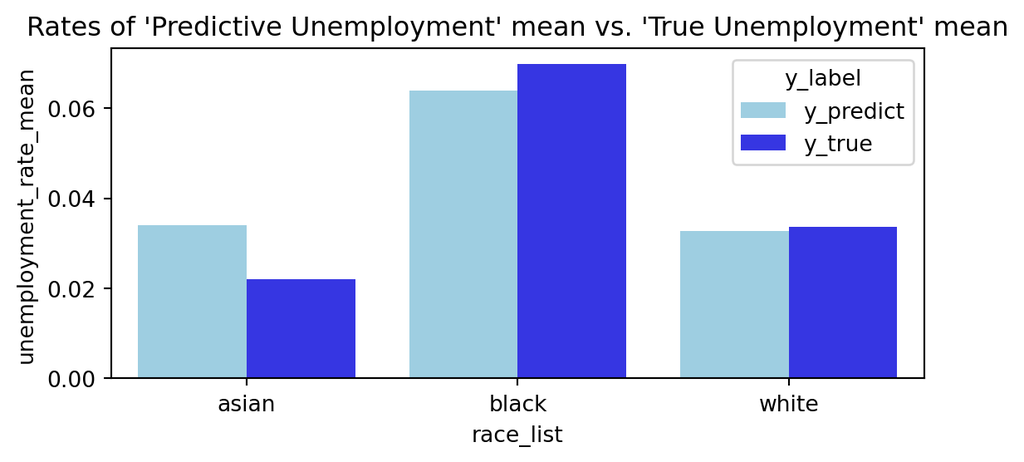

Figure 8: Bar Plot - Predictive Unemployment Rate vs. True Rate By Races

```python
black_obs = race_test_idata.constant_data['black_obs'].values
white_obs = race_test_idata.constant_data['white_obs'].values
asian_obs = race_test_idata.constant_data['asian_obs'].values

race_list = [
    'black' if b == 1 else
    'white' if w == 1 else
    'asian' if a == 1 else None
    for b, w, a in zip(black_obs, white_obs, asian_obs)
]

rate_df = pd.DataFrame({
    'race_list': race_list,
    'y_predict': race_test_idata.posterior_predictive['unemployment'].mean(dim=['chain','draw']).values,
    'y_true': race_test_idata.observed_data['unemployment'].values
    })
race_rate_df = rate_df.groupby('race_list')[['y_predict','y_true']].mean().reset_index()
race_rate_df_long = race_rate_df.melt(id_vars="race_list", var_name="y_label", value_name="unemployment_rate_mean")

# Bar plot
import matplotlib.pyplot as plt
import seaborn as sns

# Create the bar plot
fig, ax = plt.subplots(figsize=(6, 3))
sns.barplot(
    x="race_list", y='unemployment_rate_mean', hue='y_label', data=race_rate_df_long,
    alpha=0.9, ax=ax,
    palette={"y_predict": "skyblue", "y_true": "blue"}
)
ax.set_title("Rates of 'Predictive Unemployment' mean vs. 'True Unemployment' mean")
plt.tight_layout()
plt.show()
```

The bar plot above (Figure 8) demonstrates that the PGM race model predicts unemployment rates well. It accurately captures the highest unemployment rate for the Black race, closely matching the survey data. However, the model tends to overestimate the unemployment rate for the Asian group compared to the observed values.

### 4.10 Industry model - Define priors

```python
## 1. Exclude some industries and persons "not in labor force" and industries that don't have historical unemployment stats
survey_df_industry = survey_df[~survey_df['industry_name'].isin(['Construction',
                              'Mining',
                              'Other services',
                              'Agriculture, forestry, fishing, and hunting',
                              'Armed Forces'])]
survey_df_industry = survey_df_industry[survey_df_industry['employment_status_description']!="not in labor force"]
## Factorize the industry_name column to get numerical indices and names
industry_idx, industry_names = survey_df_industry['industry_name'].factorize()
survey_df_industry['industry_idx'] = industry_idx
## Map EmploymentStatus to numerical (0 for Employed, 1 for Unemployed)
survey_df_industry['unemployment_status'] = survey_df_industry['employment_status_description'].map({'employed': 0, 'unemployed': 1})

## 2. Get the prior means and sds of unemployment rates by industries from the historical monthly statistics (exlcuding 2020-2021)
df_industry_monthly_ur = df_industry[~df_industry['Industry'].isin(['construction',
                              'mining_quarrying_and_oil_and_gas_ extraction',
                              'other_services',
                              'agricultural',
                              'self_employed',
                              'non_durable_goods',
                              'durable_goods'])]

ur_by_industry = pd.DataFrame(df_industry_monthly_ur.groupby('Industry', as_index=False).agg(
    mean_ur = ('Unemployment_rate','mean'),
    sd_ur = ('Unemployment_rate', 'std')
))
 # modify the industry name column to align with industry_names
ur_by_industry['Industry']=['Educational and health services',
                            'Financial activities',
                            'Public administration',
                            'Information',
                            'Leisure and hospitality',
                            'Manufacturing',
                            'Professional and business services',
                            'Transportation and utilities',
                            'Wholesale and retail trade']
# Logit transformation function
def logit(p):
    return np.log(p / (1 - p))
ur_by_industry['mean_ur_logit'] = logit(ur_by_industry['mean_ur']/100)
ur_by_industry['sd_ur_logit'] = logit(ur_by_industry['sd_ur']/100)

# priors
ur_by_industry_copy = ur_by_industry.copy()
ur_by_industry_copy = ur_by_industry_copy.set_index('Industry')
prior_mu_alpha_vals = np.array([ur_by_industry_copy.loc[ind, 'mean_ur_logit'] for ind in industry_names])
prior_sigma_alpha_vals = np.array([ur_by_industry_copy.loc[ind, 'sd_ur_logit'] for ind in industry_names])
```

### 4.11 Industry model - Train-test split

```python
from sklearn.model_selection import train_test_split
train_df_industry_survey, test_df_industry_survey = train_test_split(survey_df_industry, test_size=0.2, random_state=42)
```

### 4.12 Industry model - Define the Adaptive pooling PyMC model

```python
# Define the PGM model with train data
coords = {"industry": industry_names}
with pm.Model(coords=coords) as unemployment_industry_model:
    industry_idx_obs = pm.Data("industry_idx_obs", X_train_ind['industry_idx'], dims="obs_id")
    # Global Priors
    sigma = pm.Exponential("sigma", 1) # standard deviation for alpha_industry
    # Industry-Specific Parameters - observed industry means
    mu_alpha_industry = pm.Data("mu_alpha_industry", prior_mu_alpha_vals, dims="industry") # history industry means
    alpha_industry = pm.Normal("alpha_industry",
                                mu=mu_alpha_industry, # historical industry means distribution
                                sigma=sigma,
                                dims="industry")
    # Probability of unemployment of each industry determined by alpha_industry
    p_unemployment = pm.Deterministic("p_unemployment", pm.math.invlogit(alpha_industry[industry_idx_obs]), dims='obs_id')
    unemployment_obs = pm.Data("unemployment_obs", y_train_ind, dims="obs_id")
    # Observed data - unemployment status
    unemployment = pm.Bernoulli("unemployment", p=p_unemployment, observed=unemployment_obs, dims="obs_id")
```

### 4.13 Industry model - Visualize PGM

```python
## 4.Visualize the PGM
pm.model_to_graphviz(unemployment_industry_model)
```

[figure not shown]

### 4.14 Industry model - Estimate model parameters

```python
print("Starting Industry Model Sampling...")
with unemployment_industry_model:
    industry_idata = pm.sample(tune = 500, draws=500, random_seed=5650) # reduce the draws due to the size of the data
```

```
Starting Industry Model Sampling...
```

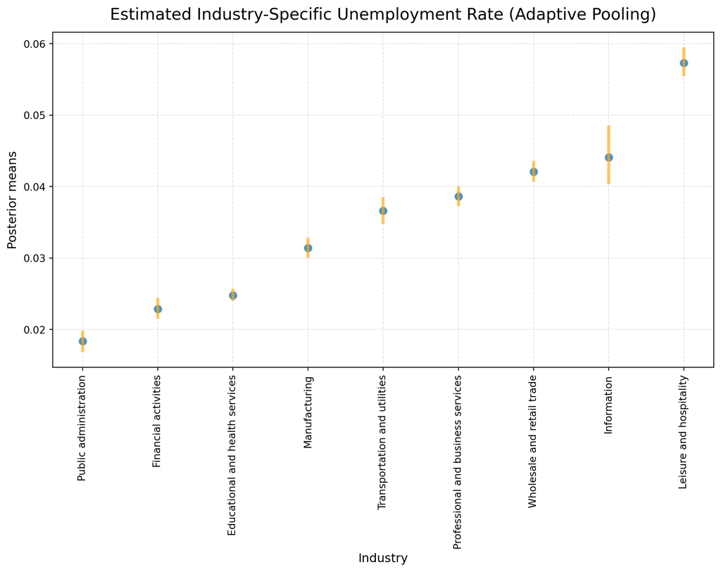

Figure 9: Estimated Industry-Specific Unemployment Rate (Adaptive Pooliing)

```python
# Posterior mean
industry_idata_post_mean = industry_idata.posterior.mean(dim=("chain", "draw"))
industry_idata_post_mean_iter = industry_idata_post_mean.sortby("alpha_industry")
industry_idata_post_mean_iter['alpha_prob'] = 1 / (1 + np.exp(-industry_idata_post_mean_iter['alpha_industry']))
industry_idata_post_mean.to_dataframe()
industry_idata_post_mean_hdi = az.hdi(industry_idata)
industry_idata_post_mean_hdi_iter = industry_idata_post_mean_hdi.sortby(industry_idata_post_mean_iter.alpha_industry)
industry_idata_post_mean_hdi_iter['alpha_prob']=1 / (1 + np.exp(-industry_idata_post_mean_hdi_iter['alpha_industry']))
industry_idata_post_mean_hdi_iter.to_dataframe()

# Plot the posterior alpha_industry (mean of unemployment)
fig, ax = plt.subplots(figsize=(10, 8))
industry_idata_post_mean_iter.plot.scatter(x='industry', y="alpha_prob", ax=ax, alpha=0.8, s=80)
ax.vlines(
    np.arange(industry_names.size),
    industry_idata_post_mean_hdi_iter.alpha_prob.sel(hdi="lower"),
    industry_idata_post_mean_hdi_iter.alpha_prob.sel(hdi="higher"),
    color="orange",
    alpha=0.6,
    linewidth=3
)
ax.grid(True, linestyle='--', alpha=0.6, color='lightgray')
ax.tick_params(axis='x', labelsize=10, rotation=90)
ax.set_xlabel('Industry', fontsize = 12)
ax.set_ylabel('Posterior means', fontsize = 12)
ax.set_title("Estimated Industry-Specific Unemployment Rate (Adaptive Pooling)", y=1.02, fontsize=16)
plt.tight_layout()
plt.show()
```